# Opis metodologii

BB

30 marca 2016

## Ranking szkół

Ranking szkół w zawężeniu do placówek z wybranego regionu odbywa się na podstawie wyników maturalnych uczniów. Sporządzając listę najlepszych szkół pod kątem danego kierunku, uwzględnia się jedynie uczniów, którzy podchodzili do tych egzaminów maturalnych, które pojawiają się w wymaganiach rekrutacyjnych danej uczelni, bądź tych, bez których uczeń nie miałby realnej żadnej szansy dostania się na wybrane studia. Dla każdego uwzględnianego ucznia wylicza się teoretyczny wynik w procesie rekrutacji na dany kierunek.

Dla matematyki/informatyki na UW jest to

$0.1 \cdot max(0.6 \cdot PL_{podst}, PL_{rozsz})$ + $0.1 \cdot max(0.6 \cdot MAT_{podst}, MAT_{rozsz})$ + $0.1 \cdot max(0.6 \cdot ANG_{podst}, ANG_{rozsz})$ + $0.2 \cdot max(MAT_{rozsz}, INF_{rozsz})$ + $0.5 \cdot max(MAT_{rozsz}, INF_{rozsz}, PL_{rozsz}, ANG_{rozsz}, FIZ_{rozsz}, BIO_{rozsz}, CHEM_{rozsz})$.

Dla matematyki/informatyki na MiNI jest to

$max(0.5 \cdot MAT_{podst}, MAT_{rozsz})$ + $0.25 \cdot max(0.5 \cdot ANG_{podst}, ANG_{rozsz})$ + $max(FIZ_{rozsz}, INF_{rozsz}, 0.75 \cdot CHEM_{rozsz}, 0.5 \cdot BIO_{rozsz})$.

Dla matematyki/informatyki na UJ jest to suma dwóch największych liczb spośród

$max(0.5 \cdot MAT_{podst}, MAT_{rozsz})$, $max(0.5 \cdot INF_{podst}, INF_{rozsz})$, $max(0.5 \cdot FIZ_{podst}, FIZ_{rozsz})$, $max(0.5 \cdot BIO_{podst}, BIO_{rozsz})$, $max(0.5 \cdot CHEM_{podst}, CHEM_{rozsz})$.

Dla matematyki/informatyki na UKSW jest to

$max(0.4 \cdot MAT_{podst}, 0.8 \cdot MAT_{rozsz})$ + $max(0.1 \cdot ANG_{podst}, 0.2 \cdot ANG_{rozsz})$.

Szkołą dobrze przygotowującą na dany kierunek jest szkoła, której duża część uczniów uzyskuje wysoki na tle pozostałych wynik w procesie rekrutacyjnym na tenże kierunek oraz standardowe odchylenie wyników w tej szkole jest stosunkowo niewielkie.

Wysoki procent uczniów z bardzo dobrym rezultatem świadczy o tym, że w szkole znajduje się dużo zdolnych osób, ale także o wysokiej jakości kształcenia szkoły. Im więcej jednostek wybitnych w klasie, tym wyższy może być poziom nauczania. Przeciętny uczeń zyskuje na tym, mając możliwość zdobycia szerszej wiedzy z wykładanych przedmiotów oraz zmuszając się do intensywniejszej nauki. Szkoły, które jedynie skupiają zdolne osoby, nie oferując dobrego przygotowania do egzaminów maturalnych nie są szkołami dobrymi, gdyż wyniki uczniów tej szkoły będą dość wyraźnie podzielone na wysokie rezultaty wybitnie zdolnych jednostek oraz niskie nieodpowiednio przygotowanych, mniej uzdolnionych kolegów.

W oparciu o podobne założenia, swoje rankingi szkół budują Perspektywy.

## Prezentacja danych

**Pobranie danych uczniów o najwyższych wynikach w procesie rekrutacji**

```r
mimuw_best_150 <- mimuw_classify %>% arrange(desc(mimuw_wynik)) %>% head(150)
mini_best_150 <- mini_classify %>% arrange(desc(mini_wynik)) %>% head(150)
uj_best_150 <- uj_classify %>% arrange(desc(uj_wynik)) %>% head(150)
uksford_best_150 <- uksford_classify %>% arrange(desc(uksford_wynik)) %>% head(150)
```

**Pobranie informacji o medianie wyników w procesie rekrutacji dla szkół**

```r
mimuw_best_avg <- mimuw_classify %>% group_by(id_szkoly) %>%
                  summarise(median_score = median(mimuw_wynik)) %>%
                  arrange(desc(median_score)) %>%
                  head(5) %>% merge(mimuw_classify, by = "id_szkoly")
```

```r
mini_best_avg <- mini_classify %>% group_by(id_szkoly) %>%
                  summarise(median_score = median(mini_wynik)) %>%
                  arrange(desc(median_score)) %>%
                  head(5) %>% merge(mini_classify, by = "id_szkoly")
```

```r
uj_best_avg <- uj_classify %>% group_by(id_szkoly) %>%
                  summarise(median_score = median(uj_wynik)) %>%
                  arrange(desc(median_score)) %>%
                  head(5) %>% merge(uj_classify, by = "id_szkoly")
```

```r
uksford_best_avg <- uksford_classify %>% group_by(id_szkoly) %>%
                  summarise(median_score = median(uksford_wynik)) %>%
                  arrange(desc(median_score)) %>%
                  head(5) %>% merge(uksford_classify, by = "id_szkoly")
```

**Zestawienie podstawowej matury z polskiego do ogólnego wyniku rekrutacji na matematykę/informatykę dla 150 najlepszych uczniów**

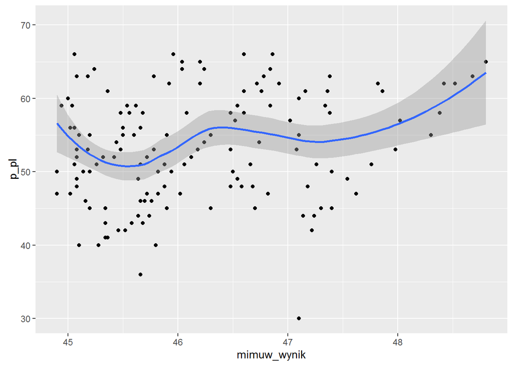

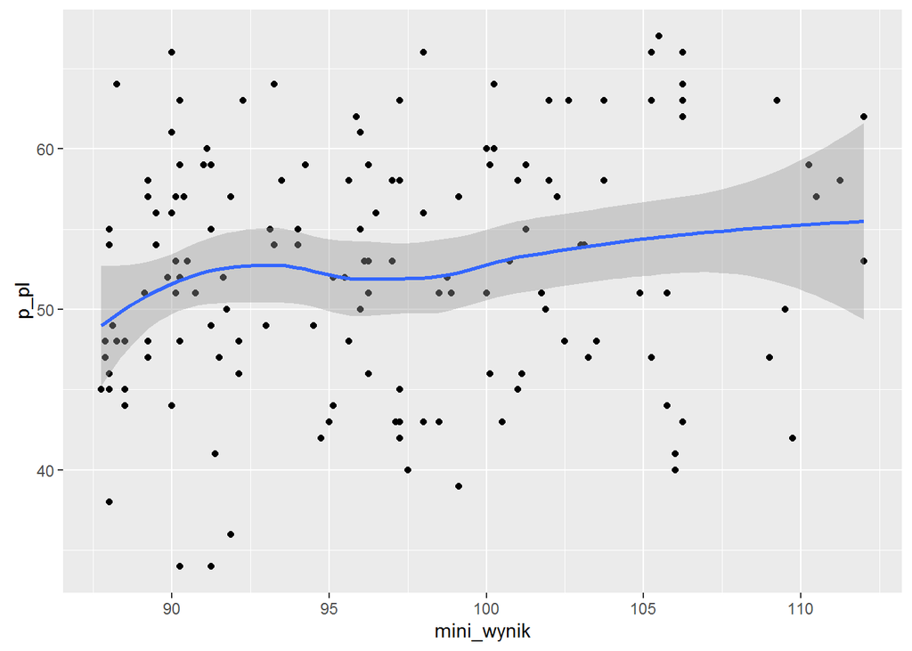

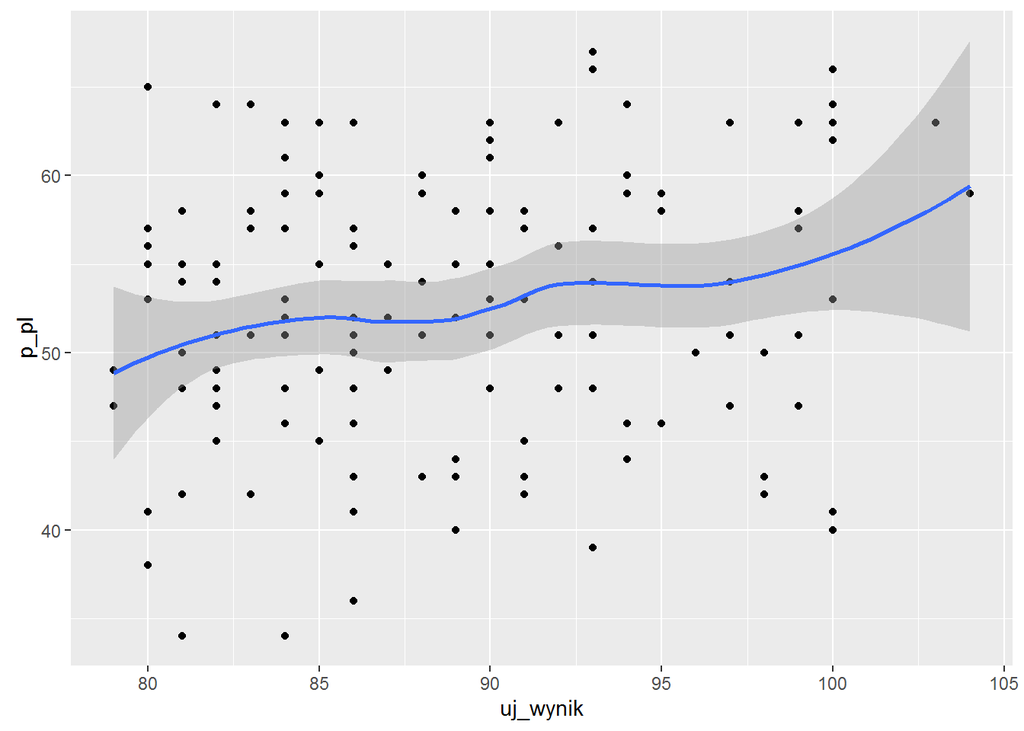

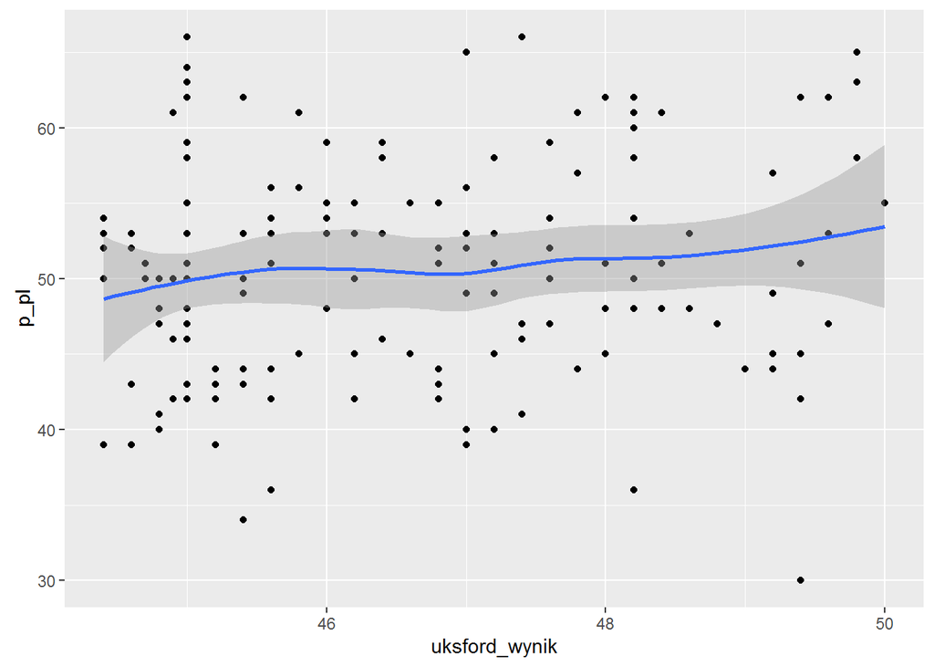

**Rozkład wyników poszczególnych matur dla 5 najlepszych szkół**

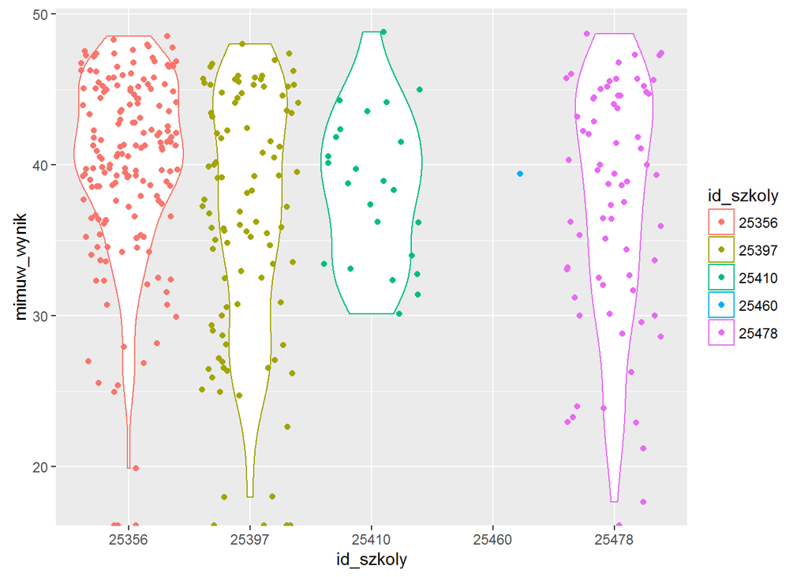

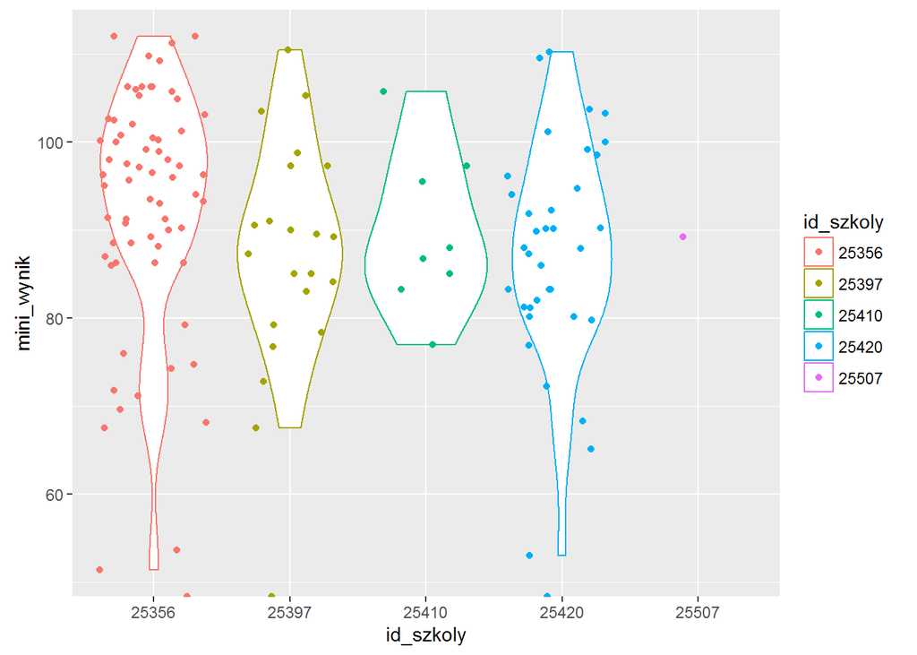

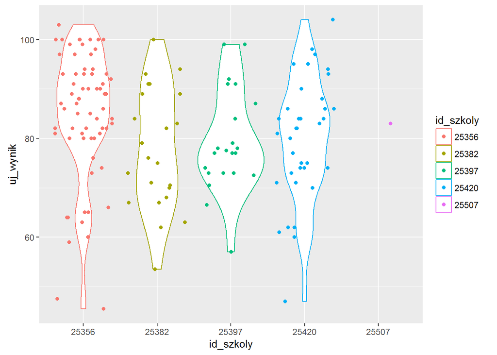

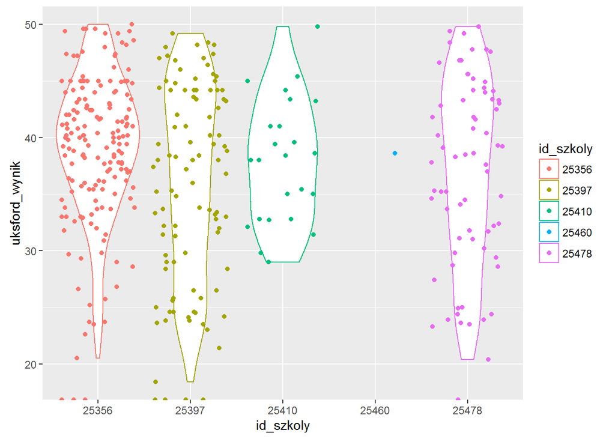

**Zestawienie podstawowej matury z polskiego do ogólnego wyniku w procesie rekrutacji dla uczniów w 5 najlepszych szkołach**

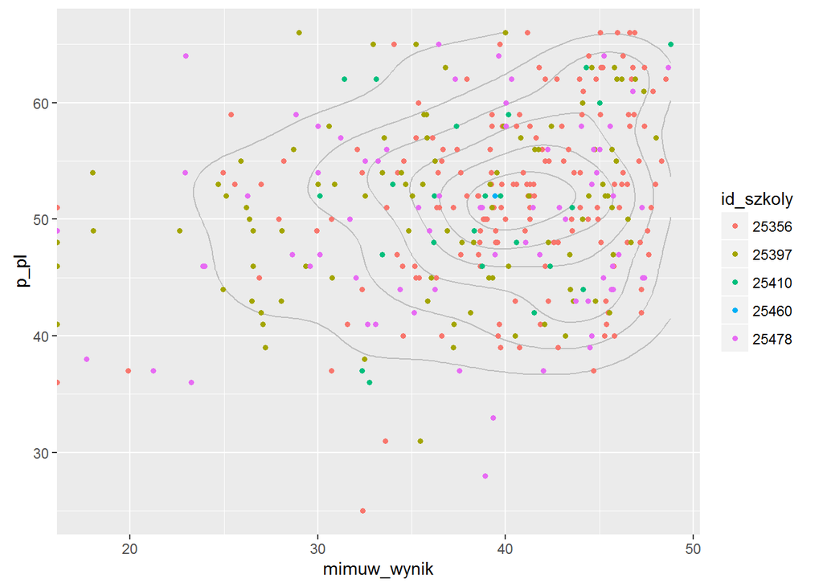

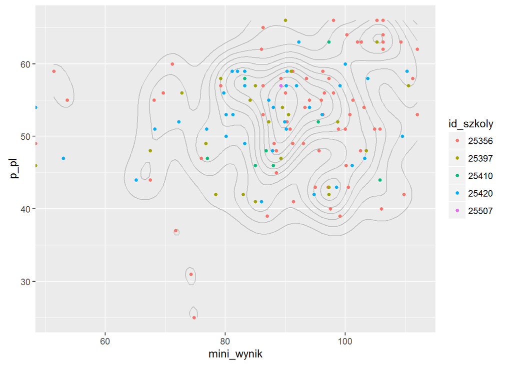

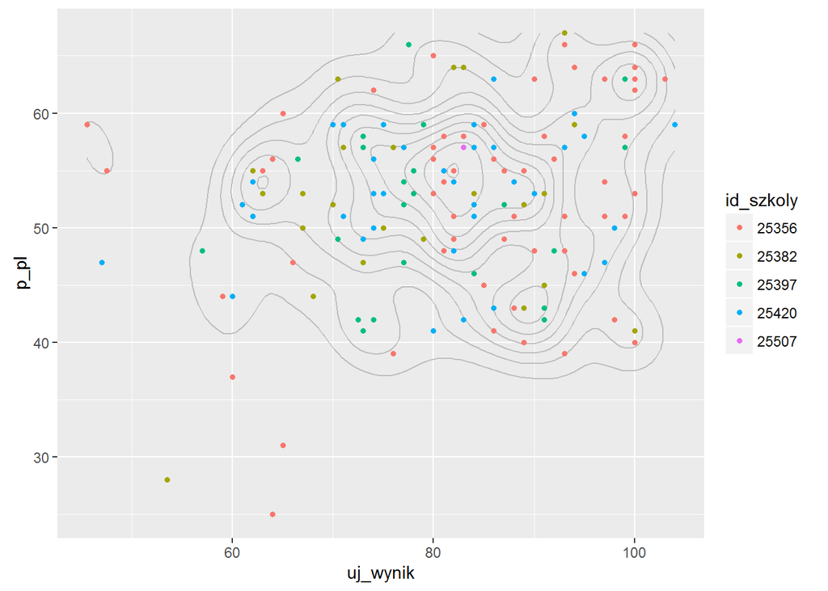

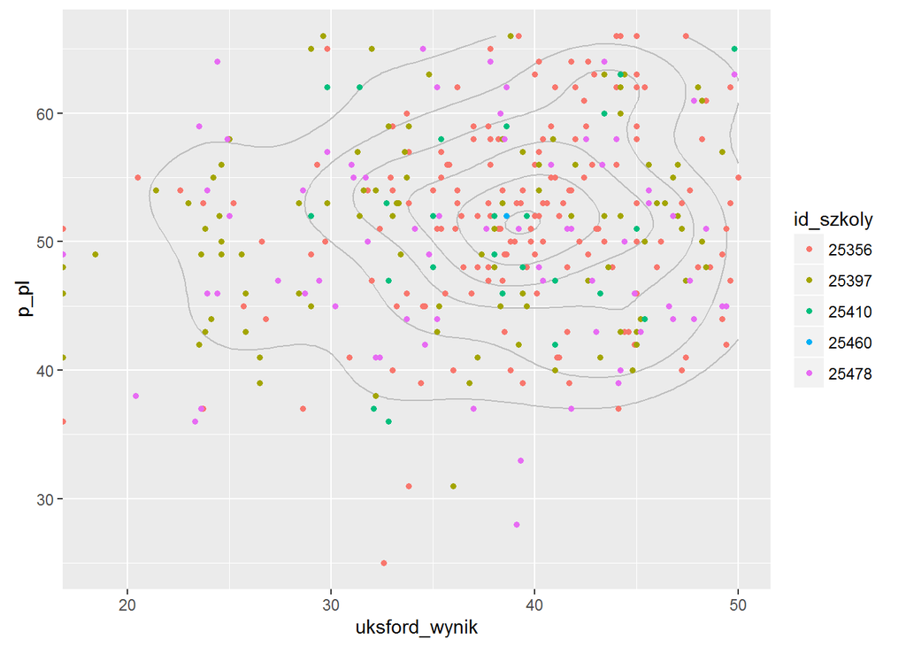

**Zestawienie rozszerzonej matury z angielskiego do rozszerzonej matury z matematyki dla uczniów w 5 najlepszych szkołach pod kątem przygotowania na studia matematyczne/informatyczne na MIMUW**

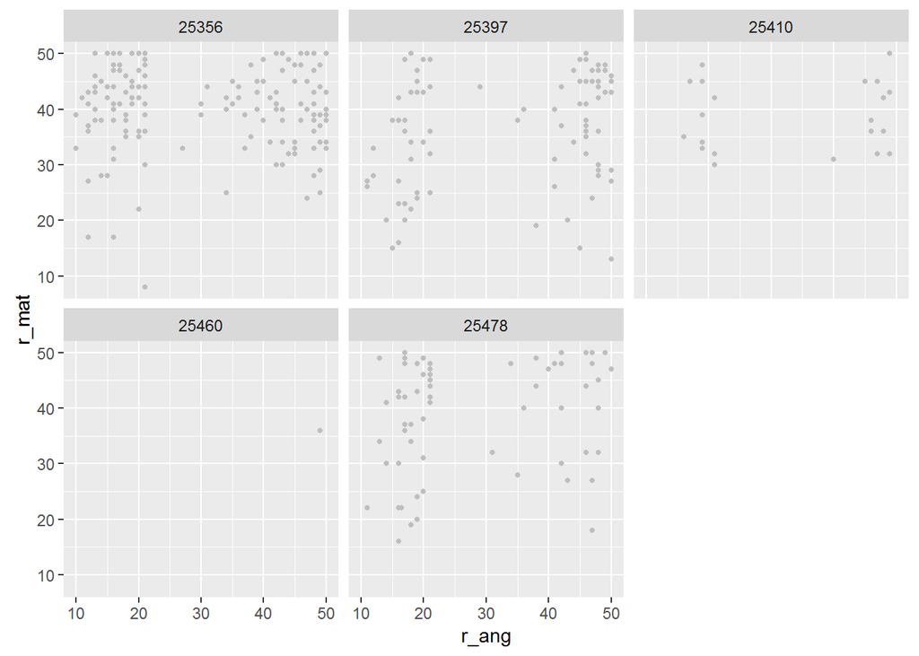